# Predicting Match results with Poisson Distribution

# Match Prediction through Poisson Distribution

# Question to answer

Can we predict premier league match results solely on the history of how many goals each team scored from when they were playing away and home?

# Cleaning Match Results data

The data was given from kaggle, and therefore did not have much cleaning to do. However, tidying the data was necesary for future use. The data given from different seasons were each given in separate csv files and contained different columns. Therefore finding the set of columns that appeared in all dataframes and joining them togeether was necessary. The only columns that had different data formats over each csv was the date format. All dates were modified to be the YYYY-MM-DD format.

## Import Data

1. Import data from csv files
2. Add a season column for each file
3. find common columns and concatenate
4. Unify Date column format

```python
import pandas as pd

df_10 = pd.read_csv('./Datasets/2010-11.csv')
df_11 = pd.read_csv('./Datasets/2011-12.csv')
df_12 = pd.read_csv('./Datasets/2012-13.csv')
df_13 = pd.read_csv('./Datasets/2013-14.csv')
df_14 = pd.read_csv('./Datasets/2014-15.csv')
df_15 = pd.read_csv('./Datasets/2015-16.csv')
df_16 = pd.read_csv('./Datasets/2016-17.csv')
df_17 = pd.read_csv('./Datasets/2017-18.csv')
df_18 = pd.read_csv('./Datasets/2018-19.csv')
df_19 = pd.read_csv('./Datasets/2019-20.csv')
df_20 = pd.read_csv('./Datasets/2020-21.csv')
df_21 = pd.read_csv('./Datasets/2021-22.csv')


# Add season column for future use
for z in range(10,22):
    exec(f'df_{z}["Season"] = {z}')


# Only concatenate columns that all dataframes have
a = df_10.columns
b = df_11.columns
c = df_12.columns
d = df_13.columns
e = df_14.columns
f = df_15.columns
g = df_16.columns
h = df_17.columns
i = df_18.columns
j = df_19.columns
k = df_20.columns
l = df_21.columns

common_columns =list(set(a).intersection(b,c,d,e,f,g,h,i,j,k,l))

for i in range(10,22):
    exec(f'mod_{i} = df_{i}[common_columns]')

final_df = pd.concat([mod_10,mod_11,mod_12,mod_13,mod_14,mod_15,mod_16,mod_17,mod_18,mod_19,mod_20,mod_21])



# Make all date format the same
final_df['Date'] = pd.to_datetime(final_df['Date'])
final_df.columns.sort_values()
```

```
Index(['AC', 'AF', 'AR', 'AS', 'AST', 'AY', 'AwayTeam', 'B365A', 'B365D',
       'B365H', 'BWA', 'BWD', 'BWH', 'Date', 'Div', 'FTAG', 'FTHG', 'FTR',
       'HC', 'HF', 'HR', 'HS', 'HST', 'HTAG', 'HTHG', 'HTR', 'HY', 'HomeTeam',
       'IWA', 'IWD', 'IWH', 'Referee', 'Season', 'VCA', 'VCD', 'VCH', 'WHA',
       'WHD', 'WHH'],
      dtype='object')
```

## Idendify various match prediction sources

Based on the column names printed above and using the “Dataset-Explanation.txt” file, we can tell that we have 5 sources in the merged dataset that predict the odds of the outcome of the matches. - B365 = Bet365 - BW = Bet&Win - IW = Interwetten - WH = William Hill - VC = VC Bet

## Forming Final dataset

For out final dataset, we will only keep columns necessary for our analysis. We will only use the odds predicted by B365 for convenience, and will keep essential information such as the season, hometeam, away team, results, goals scored, date etc.

```python
final_df_mod = final_df[['Season','HomeTeam','AwayTeam','Referee','FTR','FTHG','FTAG','Date','B365H','B365A','B365D']]
output_path = './Datasets/results_MOD.csv'
final_df_mod.to_csv(output_path, index=False)
final_df_mod.head(20)
```

|  | Season | HomeTeam | AwayTeam | Referee | FTR | FTHG | FTAG | Date | B365H | B365A | B365D |
| --- | --- | --- | --- | --- | --- | --- | --- | --- | --- | --- | --- |
| 0 | 10 | Aston Villa | West Ham | M Dean | H | 3 | 0 | 2010-08-14 | 2.00 | 4.00 | 3.30 |
| 1 | 10 | Blackburn | Everton | P Dowd | H | 1 | 0 | 2010-08-14 | 2.88 | 2.50 | 3.25 |
| 2 | 10 | Bolton | Fulham | S Attwell | D | 0 | 0 | 2010-08-14 | 2.20 | 3.40 | 3.30 |
| 3 | 10 | Chelsea | West Brom | M Clattenburg | H | 6 | 0 | 2010-08-14 | 1.17 | 17.00 | 7.00 |
| 4 | 10 | Sunderland | Birmingham | A Taylor | D | 2 | 2 | 2010-08-14 | 2.10 | 3.60 | 3.30 |
| 5 | 10 | Tottenham | Man City | A Marriner | D | 0 | 0 | 2010-08-14 | 2.40 | 3.00 | 3.30 |
| 6 | 10 | Wigan | Blackpool | M Halsey | A | 0 | 4 | 2010-08-14 | 1.83 | 4.50 | 3.50 |
| 7 | 10 | Wolves | Stoke | L Probert | H | 2 | 1 | 2010-08-14 | 2.30 | 3.20 | 3.25 |
| 8 | 10 | Liverpool | Arsenal | M Atkinson | D | 1 | 1 | 2010-08-15 | 2.50 | 2.88 | 3.25 |
| 9 | 10 | Man United | Newcastle | C Foy | H | 3 | 0 | 2010-08-16 | 1.25 | 15.00 | 5.50 |
| 10 | 10 | Arsenal | Blackpool | M Jones | H | 6 | 0 | 2010-08-21 | 1.17 | 19.00 | 7.00 |
| 11 | 10 | Birmingham | Blackburn | M Oliver | H | 2 | 1 | 2010-08-21 | 2.20 | 3.40 | 3.25 |
| 12 | 10 | Everton | Wolves | L Mason | D | 1 | 1 | 2010-08-21 | 1.50 | 7.00 | 4.00 |
| 13 | 10 | Stoke | Tottenham | C Foy | A | 1 | 2 | 2010-08-21 | 3.40 | 2.20 | 3.30 |
| 14 | 10 | West Brom | Sunderland | K Friend | H | 1 | 0 | 2010-08-21 | 2.50 | 2.88 | 3.25 |
| 15 | 10 | West Ham | Bolton | A Marriner | A | 1 | 3 | 2010-08-21 | 2.25 | 3.25 | 3.30 |
| 16 | 10 | Wigan | Chelsea | M Dean | A | 0 | 6 | 2010-08-21 | 15.00 | 1.22 | 6.00 |
| 17 | 10 | Fulham | Man United | P Walton | D | 2 | 2 | 2010-08-22 | 6.00 | 1.57 | 4.00 |
| 18 | 10 | Newcastle | Aston Villa | M Atkinson | H | 6 | 0 | 2010-08-22 | 3.20 | 2.30 | 3.25 |
| 19 | 10 | Man City | Liverpool | P Dowd | H | 3 | 0 | 2010-08-23 | 2.38 | 3.10 | 3.25 |

## How to navigate the project

After some basic data interpretation, I decided to evaluate the proejct in two different directions. First, I will predict a value of the match and I will compare this to

1. The actual result of the match in the “FTR” column
2. What the B365 predicted(Which outcome had the lowest odds)

# EDA

## Question!!

By looking at the dataset, one question came into mind.

Do the predictions made by B365 every predict a draw..? It seems the lowest odds are correlated to the actual results of the match. For example if B365H is the lowest out of the three columns (B365H, B365A, and B365D), they are actually predicting that the home team would win.

Lets find out if they predict any draws!

```python
min_column = final_df_mod[['B365H','B365A','B365D']].idxmin(axis=1)
draws_predicted = sum(min_column.str[-1] == 'D')
print("Number of Draws predicted by B365: ", draws_predicted)
```

```
Number of Draws predicted by B365:  0
```

*There were no draws predicted!*

My next train of thought was, although they never predicted a draw as the most likely result, maybe I can force a ‘draw’ prediction based on what the B365 predicted on matches that where actually tied.

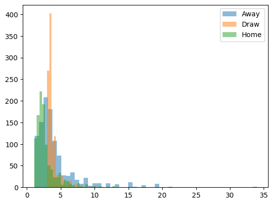

```python
import matplotlib.pyplot as plt
A = final_df_mod[final_df_mod['FTR']=='D'].B365A
D = final_df_mod[final_df_mod['FTR']=='D'].B365D
H = final_df_mod[final_df_mod['FTR']=='D'].B365H

plt.hist(A, bins=50, alpha=0.5, label='Away')
plt.hist(D, bins=30, alpha=0.5, label='Draw')
plt.hist(H, bins=30, alpha=0.5, label='Home')
plt.legend()
plt.show()
```

Based on the graph, it does seem like there is a difference in the mode in which the odds are distributed. The mode of odds for the three results are Home<Away<Draw.

However, is this statistically significant?  
I ran a t-test to check whether this was a significant observation.

```python
import scipy.stats as stats

# Perform independent samples t-test
t_statistic, p_value = stats.ttest_ind(D, A, alternative='less')

# Display results
print(f"t-statistic: {t_statistic}")
print(f"p-value: {p_value}")

# Interpret the results
if p_value < 0.05:
    print("The difference between the groups is statistically significant.")
else:
    print("There is no significant difference between the groups.")
```

```
t-statistic: -3.2889974365814885
p-value: 0.0005110860089710148
The difference between the groups is statistically significant.
```

**Based on this observaiton, we may want to change our dependent variable as a binary variable when evaluating against the B365 odds or even the actual results to see if our model did better than B365.**

# Match prediction using Poisson Distribution(Single Example)

What I will attempt to do is predict the amount of goals a team will score using the poisson distribution, but I will use column HomeTeam, AwayTeam, Goals, and Home(Y/N) as independent variables to predict the amount of goals scored.

```python
# Import modules
import pandas as pd
import matplotlib.pyplot as plt
import numpy as np
import seaborn as sns
from scipy.stats import poisson, skellam
import statsmodels.api as sm
import statsmodels.formula.api as smf
from sklearn.metrics import precision_score, recall_score, f1_score, accuracy_score, confusion_matrix, classification_report
```

## Manipulate dataset

The goal of this section is to manipulate the dataset so that we can feed it into the glm algorithm that we will use. We want to use the two opposing teams, and which team had the home advantage into the algorithm as independent variables to predict out dependent variable which is number of goals scored. The dataset will be manipulated so that each match is represented twice to create ‘home’ as a variable. Each column is defined as follows

1. team : One of the given teams in the matchup
2. opponent : The other team in the matchup
3. goals : how many goals the ‘team’ scored
4. home : whether the ‘team’ is the home team or not

```python
# Leave only 4 columns that we will use
df = final_df_mod[['HomeTeam','AwayTeam','FTHG','FTAG']]
df = df.rename(columns={'FTHG':'HomeGoals','FTAG':'AwayGoals'})

# Manipulate dataset so each game is represented twice with a column indicating home or not
goal_model_data = pd.concat([df[['HomeTeam','AwayTeam','HomeGoals']].assign(home=1).rename(
    columns={'HomeTeam':'team','AwayTeam':'opponent','HomeGoals':'goals'}),
    df[['AwayTeam','HomeTeam','AwayGoals']].assign(home=0).rename(
        columns={'AwayTeam':'team','HomeTeam':'opponent','AwayGoals':'goals'})])

goal_model_data.head()
```

|  | team | opponent | goals | home |
| --- | --- | --- | --- | --- |
| 0 | Aston Villa | West Ham | 3 | 1 |
| 1 | Blackburn | Everton | 1 | 1 |
| 2 | Bolton | Fulham | 0 | 1 |
| 3 | Chelsea | West Brom | 6 | 1 |
| 4 | Sunderland | Birmingham | 2 | 1 |

## Example of how goals are predicted

### Creating a poisson distribution model with our input data

The summary portrays how since the ‘team’ and ‘opponent’ columns are categorical variables, each category was made as a dummy variable and fed into the algorithm. Therefore there are coefficients for each club twice. Once as ‘team’ and once as ‘opponent’.

```python
poisson_model = smf.glm(formula="goals~home+team+opponent", data = goal_model_data, family=sm.families.Poisson()).fit()
poisson_model.summary()
```

Generalized Linear Model Regression Results

| Dep. Variable: | goals | No. Observations: | 8440 |
| --- | --- | --- | --- |
| Model: | GLM | Df Residuals: | 8364 |
| Model Family: | Poisson | Df Model: | 75 |
| Link Function: | Log | Scale: | 1.0000 |
| Method: | IRLS | Log-Likelihood: | -12225. |
| Date: | Fri, 15 Dec 2023 | Deviance: | 9519.1 |
| Time: | 13:04:32 | Pearson chi2: | 8.29e+03 |
| No. Iterations: | 5 | Pseudo R-squ. (CS): | 0.1485 |
| Covariance Type: | nonrobust |  |  |

|  | coef | std err | z | P>\|z\| | [0.025 | 0.975] |
| --- | --- | --- | --- | --- | --- | --- |
| Intercept | 0.2865 | 0.060 | 4.768 | 0.000 | 0.169 | 0.404 |
| team[T.Aston Villa] | -0.4648 | 0.063 | -7.322 | 0.000 | -0.589 | -0.340 |
| team[T.Birmingham] | -0.6432 | 0.169 | -3.810 | 0.000 | -0.974 | -0.312 |
| team[T.Blackburn] | -0.3907 | 0.110 | -3.559 | 0.000 | -0.606 | -0.176 |
| team[T.Blackpool] | -0.2261 | 0.140 | -1.613 | 0.107 | -0.501 | 0.049 |
| team[T.Bolton] | -0.3509 | 0.108 | -3.255 | 0.001 | -0.562 | -0.140 |
| team[T.Bournemouth] | -0.3289 | 0.080 | -4.095 | 0.000 | -0.486 | -0.171 |
| team[T.Brentford] | -0.3328 | 0.149 | -2.232 | 0.026 | -0.625 | -0.041 |
| team[T.Brighton] | -0.5040 | 0.086 | -5.869 | 0.000 | -0.672 | -0.336 |
| team[T.Burnley] | -0.6356 | 0.077 | -8.212 | 0.000 | -0.787 | -0.484 |
| team[T.Cardiff] | -0.7096 | 0.150 | -4.718 | 0.000 | -1.004 | -0.415 |
| team[T.Chelsea] | 0.0068 | 0.051 | 0.132 | 0.895 | -0.094 | 0.107 |
| team[T.Crystal Palace] | -0.4622 | 0.065 | -7.075 | 0.000 | -0.590 | -0.334 |
| team[T.Everton] | -0.2727 | 0.055 | -4.932 | 0.000 | -0.381 | -0.164 |
| team[T.Fulham] | -0.4766 | 0.075 | -6.320 | 0.000 | -0.624 | -0.329 |
| team[T.Huddersfield] | -0.9052 | 0.166 | -5.440 | 0.000 | -1.231 | -0.579 |
| team[T.Hull] | -0.6154 | 0.103 | -5.976 | 0.000 | -0.817 | -0.414 |
| team[T.Leeds] | -0.2333 | 0.105 | -2.226 | 0.026 | -0.439 | -0.028 |
| team[T.Leicester] | -0.1155 | 0.061 | -1.899 | 0.058 | -0.235 | 0.004 |
| team[T.Liverpool] | 0.0637 | 0.051 | 1.261 | 0.207 | -0.035 | 0.163 |
| team[T.Man City] | 0.2192 | 0.049 | 4.503 | 0.000 | 0.124 | 0.315 |
| team[T.Man United] | -0.0211 | 0.052 | -0.410 | 0.682 | -0.122 | 0.080 |
| team[T.Middlesbrough] | -0.8976 | 0.196 | -4.579 | 0.000 | -1.282 | -0.513 |
| team[T.Newcastle] | -0.4172 | 0.060 | -7.004 | 0.000 | -0.534 | -0.300 |
| team[T.Norwich] | -0.6175 | 0.078 | -7.868 | 0.000 | -0.771 | -0.464 |
| team[T.QPR] | -0.5741 | 0.100 | -5.728 | 0.000 | -0.771 | -0.378 |
| team[T.Reading] | -0.4653 | 0.157 | -2.964 | 0.003 | -0.773 | -0.158 |
| team[T.Sheffield United] | -0.8461 | 0.149 | -5.679 | 0.000 | -1.138 | -0.554 |
| team[T.Southampton] | -0.3521 | 0.060 | -5.820 | 0.000 | -0.471 | -0.234 |
| team[T.Stoke] | -0.5161 | 0.066 | -7.782 | 0.000 | -0.646 | -0.386 |
| team[T.Sunderland] | -0.5351 | 0.070 | -7.640 | 0.000 | -0.672 | -0.398 |
| team[T.Swansea] | -0.4385 | 0.068 | -6.466 | 0.000 | -0.571 | -0.306 |
| team[T.Tottenham] | -0.0279 | 0.052 | -0.539 | 0.590 | -0.129 | 0.074 |
| team[T.Watford] | -0.5128 | 0.079 | -6.463 | 0.000 | -0.668 | -0.357 |
| team[T.West Brom] | -0.4770 | 0.063 | -7.569 | 0.000 | -0.601 | -0.354 |
| team[T.West Ham] | -0.2929 | 0.057 | -5.099 | 0.000 | -0.405 | -0.180 |
| team[T.Wigan] | -0.4797 | 0.096 | -5.019 | 0.000 | -0.667 | -0.292 |
| team[T.Wolves] | -0.4895 | 0.078 | -6.291 | 0.000 | -0.642 | -0.337 |
| opponent[T.Aston Villa] | 0.3136 | 0.063 | 4.953 | 0.000 | 0.189 | 0.438 |
| opponent[T.Birmingham] | 0.2599 | 0.139 | 1.863 | 0.062 | -0.013 | 0.533 |
| opponent[T.Blackburn] | 0.4474 | 0.097 | 4.598 | 0.000 | 0.257 | 0.638 |
| opponent[T.Blackpool] | 0.5746 | 0.123 | 4.688 | 0.000 | 0.334 | 0.815 |
| opponent[T.Bolton] | 0.4197 | 0.098 | 4.264 | 0.000 | 0.227 | 0.613 |
| opponent[T.Bournemouth] | 0.3760 | 0.077 | 4.874 | 0.000 | 0.225 | 0.527 |
| opponent[T.Brentford] | 0.2204 | 0.141 | 1.558 | 0.119 | -0.057 | 0.498 |
| opponent[T.Brighton] | 0.1089 | 0.084 | 1.300 | 0.194 | -0.055 | 0.273 |
| opponent[T.Burnley] | 0.1785 | 0.072 | 2.481 | 0.013 | 0.037 | 0.320 |
| opponent[T.Cardiff] | 0.5125 | 0.108 | 4.732 | 0.000 | 0.300 | 0.725 |
| opponent[T.Chelsea] | -0.1318 | 0.067 | -1.966 | 0.049 | -0.263 | -0.000 |
| opponent[T.Crystal Palace] | 0.1927 | 0.066 | 2.902 | 0.004 | 0.063 | 0.323 |
| opponent[T.Everton] | 0.1107 | 0.063 | 1.761 | 0.078 | -0.012 | 0.234 |
| opponent[T.Fulham] | 0.3290 | 0.072 | 4.597 | 0.000 | 0.189 | 0.469 |
| opponent[T.Huddersfield] | 0.2877 | 0.118 | 2.440 | 0.015 | 0.057 | 0.519 |
| opponent[T.Hull] | 0.3307 | 0.087 | 3.807 | 0.000 | 0.160 | 0.501 |
| opponent[T.Leeds] | 0.4034 | 0.098 | 4.106 | 0.000 | 0.211 | 0.596 |
| opponent[T.Leicester] | 0.1764 | 0.069 | 2.541 | 0.011 | 0.040 | 0.313 |
| opponent[T.Liverpool] | -0.0697 | 0.066 | -1.055 | 0.291 | -0.199 | 0.060 |
| opponent[T.Man City] | -0.2275 | 0.069 | -3.291 | 0.001 | -0.363 | -0.092 |
| opponent[T.Man United] | -0.0839 | 0.066 | -1.268 | 0.205 | -0.213 | 0.046 |
| opponent[T.Middlesbrough] | 0.1738 | 0.145 | 1.199 | 0.230 | -0.110 | 0.458 |
| opponent[T.Newcastle] | 0.2890 | 0.061 | 4.699 | 0.000 | 0.168 | 0.410 |
| opponent[T.Norwich] | 0.4221 | 0.069 | 6.156 | 0.000 | 0.288 | 0.556 |
| opponent[T.QPR] | 0.4105 | 0.085 | 4.857 | 0.000 | 0.245 | 0.576 |
| opponent[T.Reading] | 0.5130 | 0.126 | 4.076 | 0.000 | 0.266 | 0.760 |
| opponent[T.Sheffield United] | 0.1270 | 0.117 | 1.088 | 0.277 | -0.102 | 0.356 |
| opponent[T.Southampton] | 0.2126 | 0.064 | 3.314 | 0.001 | 0.087 | 0.338 |
| opponent[T.Stoke] | 0.1787 | 0.067 | 2.672 | 0.008 | 0.048 | 0.310 |
| opponent[T.Sunderland] | 0.2588 | 0.068 | 3.812 | 0.000 | 0.126 | 0.392 |
| opponent[T.Swansea] | 0.2199 | 0.069 | 3.201 | 0.001 | 0.085 | 0.354 |
| opponent[T.Tottenham] | -0.0236 | 0.065 | -0.363 | 0.717 | -0.151 | 0.104 |
| opponent[T.Watford] | 0.3525 | 0.072 | 4.879 | 0.000 | 0.211 | 0.494 |
| opponent[T.West Brom] | 0.2718 | 0.063 | 4.285 | 0.000 | 0.147 | 0.396 |
| opponent[T.West Ham] | 0.2543 | 0.062 | 4.098 | 0.000 | 0.133 | 0.376 |
| opponent[T.Wigan] | 0.3979 | 0.085 | 4.674 | 0.000 | 0.231 | 0.565 |
| opponent[T.Wolves] | 0.2565 | 0.074 | 3.455 | 0.001 | 0.111 | 0.402 |
| home | 0.2264 | 0.019 | 12.110 | 0.000 | 0.190 | 0.263 |

### Club input example

Lets predict how a match would be when Manchester city and Wolverhampton play a match where Man City is the home team.

```python
home_team = 'Man City'
away_team = 'Wolves'

home_score_rate = poisson_model.predict(pd.DataFrame(data={'team': home_team, 'opponent': away_team, 'home':1}, index=[1]))
away_score_rate = poisson_model.predict(pd.DataFrame(data={'team': away_team, 'opponent': home_team, 'home':0}, index=[1]))

print(home_team + ' against ' + away_team + ' expect to score: ' + str(home_score_rate))
print(away_team + ' against ' + home_team + ' expect to score: ' + str(away_score_rate))
```

```
Man City against Wolves expect to score: 1    2.687892
dtype: float64
Wolves against Man City expect to score: 1    0.650189
dtype: float64
```

### Create array and heatmap for example

We will create a function that when an input of the model, hometeam, awayteam, and maximum goals of simulation is given, an output of an array of probabilities of the home team and away team scoring 0~maximum goals is given. Then we will visualize this with a heatmap to understand how to calculate the probability of each possibility.

```python
def simulate_match(foot_model, homeTeam, awayTeam, max_goals=10):
    home_goals_avg = foot_model.predict(pd.DataFrame(data={'team': homeTeam, 'opponent': awayTeam, 'home':1}, index=[1])).values[0]
    away_goals_avg = foot_model.predict(pd.DataFrame(data={'team': awayTeam, 'opponent': homeTeam, 'home':0}, index=[1])).values[0]
    team_pred = [[poisson.pmf(i, team_avg) for i in range(0,max_goals+1)] for team_avg in [home_goals_avg, away_goals_avg]]
    return (np.outer(np.array(team_pred[0]), np.array(team_pred[1])))
```

```python
score_matrix = simulate_match(poisson_model, home_team, away_team, max_goals = 6)
score_matrix
```

```
array([[3.55050464e-02, 2.30849846e-02, 7.50479957e-03, 1.62651228e-03,
        2.64385030e-04, 3.43800386e-05, 3.72558618e-06],
       [9.54337164e-02, 6.20499364e-02, 2.01720878e-02, 4.37188872e-03,
        7.10638303e-04, 9.24098173e-05, 1.00139718e-05],
       [1.28257743e-01, 8.33917517e-02, 2.71101927e-02, 5.87558150e-03,
        9.55059366e-04, 1.24193786e-04, 1.34582354e-05],
       [1.14914304e-01, 7.47159966e-02, 2.42897532e-02, 5.26430874e-03,
        8.55698685e-04, 1.11273145e-04, 1.20580927e-05],
       [7.72192981e-02, 5.02071251e-02, 1.63220560e-02, 3.53747282e-03,
        5.75006329e-04, 7.47725384e-05, 8.10271155e-06],
       [4.15114207e-02, 2.69902620e-02, 8.77438345e-03, 1.90166870e-03,
        3.09110937e-04, 4.01960957e-05, 4.35584208e-06],
       [1.85963666e-02, 1.20911498e-02, 3.93076528e-03, 8.51913225e-04,
        1.38476116e-04, 1.80071247e-05, 1.95133856e-06]])
```

With the heatmap below, to calculate the probabilities of each possibility [‘H’,‘D’,‘A’], we can tell that the diagonal line from upper left to lower right is the possibility of the two teams resulting in a draw. Anything under that line is ManCity scoring more than Wolverhampton, and anything above that line would be the chance of Wolverhampton(the away team) winning.

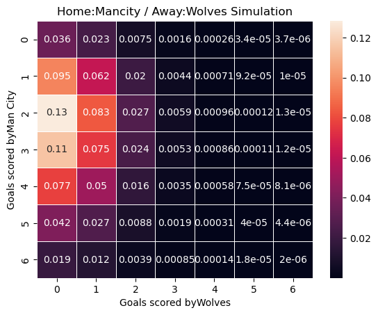

```
Predicted result of the match :  H ( Man City )
```

```python
ax = sns.heatmap(score_matrix, linewidth=0.7, annot=True)
ax.set_xlabel('Goals scored by' + away_team)
ax.set_ylabel('Goals scored by' + home_team)
ax.set_title('Home:Mancity / Away:Wolves Simulation')

plt.show()

homewin = np.sum(np.tril(score_matrix, -1))
draw = np.sum(np.diag(score_matrix))
awaywin = np.sum(np.triu(score_matrix, 1))

variables = {'H':homewin, 'D':draw, 'A':awaywin}
largest_variable = max(variables, key=variables.get)
print("Predicted result of the match : ",largest_variable, "(",home_team,")")
```

# Creating real model for prediction

## Data Manipulation

```python
df = final_df_mod[['Season','HomeTeam','AwayTeam','FTHG','FTAG']]
df = df.rename(columns={'FTHG':'HomeGoals','FTAG':'AwayGoals'})

goal_model_data = pd.concat([df[['Season','HomeTeam','AwayTeam','HomeGoals']].assign(home=1).rename(
    columns={'Season':'Season','HomeTeam':'team','AwayTeam':'opponent','HomeGoals':'goals'}),
    df[['Season','AwayTeam','HomeTeam','AwayGoals']].assign(home=0).rename(
        columns={'Season':'Season','AwayTeam':'team','HomeTeam':'opponent','AwayGoals':'goals'})])

df_pred = final_df_mod[['Season','HomeTeam','AwayTeam','FTR']]
df_pred['B365'] = final_df_mod[['B365H','B365D','B365A']].idxmin(axis=1).str[-1]
```

## Necessary Functions

```python
def simulate_match(foot_model, homeTeam, awayTeam, max_goals=10):
    """
    foot_model : Poisson distribution model to feed our data into
    homeTeam : Home Team variable
    awayTeam : Away Team variable
    max_goals : number of maximum goals to test in our poisson distribution.
    """
    home_goals_avg = foot_model.predict(pd.DataFrame(data={'team': homeTeam, 'opponent': awayTeam, 'home':1}, index=[1])).values[0]
    away_goals_avg = foot_model.predict(pd.DataFrame(data={'team': awayTeam, 'opponent': homeTeam, 'home':0}, index=[1])).values[0]
    team_pred = [[poisson.pmf(i, team_avg) for i in range(0,max_goals+1)] for team_avg in [home_goals_avg, away_goals_avg]]
    return (np.outer(np.array(team_pred[0]), np.array(team_pred[1])))

def custom_function(row):
    """
    row : each row in the dataframe that we wish to pass into the poisson model.

    Calculates the probability of each outcome [H,D,A]
    and returns the output for the result with the highest probability.
    """
    home_team = row['HomeTeam']
    away_team = row['AwayTeam']

    score_matrix = simulate_match(poisson_model, home_team, away_team, max_goals = 6)

    homewin = np.sum(np.tril(score_matrix, -1))
    draw = np.sum(np.diag(score_matrix))
    awaywin = np.sum(np.triu(score_matrix, 1))

    variables = {'H':homewin, 'D':draw, 'A':awaywin}
    largest_variable = max(variables, key=variables.get)

    return largest_variable

def modify_column(value):
    """
    A funciton to make the dependent column into a binary variable
    """
    return 'H' if value == 'H' else 'X'
```

## Training our model

### Parameter tuning

The main parameter we need to take into account when training our model is **how many season do we need to look back in order to predict this season’s results?** Since there is no guarantee that the strongest team 5 years ago will still be the best team, we need to test how far we have to look back. We will use accuracy as the evaluation metric and test all ranges from 1 to the maximum possible look back season which is 11 in our case.

```python
max_season = max(goal_model_data.Season)
min_season = min(goal_model_data.Season)
ran = max_season - min_season
accuracy = 0
f1 = 0
df_pred = final_df_mod[['Season','HomeTeam','AwayTeam','FTR']]
df_pred['B365'] = final_df_mod[['B365H','B365D','B365A']].idxmin(axis=1).str[-1]
# result_df = pd.DataFrame(columns=list(df_pred.columns))


for j in range(1,ran+1):
    result_df = pd.DataFrame(columns=list(df_pred.columns))
    for i in range(min_season+j,max_season+1):
        train = goal_model_data[(goal_model_data['Season'] < i) & (goal_model_data['Season'] >= i-j)]
        poisson_model = smf.glm(formula="goals~home+team+opponent", data = train, family=sm.families.Poisson()).fit()

        selection = pd.concat([train['team'],train['opponent']]).unique()

        test = df_pred[(df_pred['Season'] == i)]
        test = test[(test['HomeTeam'].isin(selection))&(test['AwayTeam'].isin(selection))]

        test['Prediction'] = test.apply(custom_function, axis=1)

        result_df = pd.concat([result_df,test], ignore_index=True)

    # Apply the custom function to the specified column
    result_df['FTR_mod'] = result_df['FTR'].apply(modify_column)
    result_df['Prediction_mod'] = result_df['Prediction'].apply(modify_column)

    y_true = result_df['FTR_mod']
    y_pred = result_df['Prediction_mod']

    accuracy_new = accuracy_score(y_true, y_pred)
    f1_new = f1_score(y_true, y_pred, average='weighted')

    if accuracy_new > accuracy:
        accuracy = accuracy_new
        r = j

print("Best number of seasons to look back : ", r)
print("Highest Accuracy : ", accuracy)
```

```
Best number of seasons to look back :  2
Highest Accuracy :  0.6119885139985642
```

### Training our model with optimized parameter

```python
j = r
result_df = pd.DataFrame(columns=list(df_pred.columns))

for i in range(min_season+j,max_season+1):
    train = goal_model_data[(goal_model_data['Season'] < i) & (goal_model_data['Season'] >= i-j)]
    poisson_model = smf.glm(formula="goals~home+team+opponent", data = train, family=sm.families.Poisson()).fit()

    selection = pd.concat([train['team'],train['opponent']]).unique()

    test = df_pred[(df_pred['Season'] == i)]
    test = test[(test['HomeTeam'].isin(selection))&(test['AwayTeam'].isin(selection))]

    test['Prediction'] = test.apply(custom_function, axis=1)

    result_df = pd.concat([result_df,test], ignore_index=True)

result_df['FTR_mod'] = result_df['FTR'].apply(modify_column)
result_df['B365_mod'] = result_df['B365'].apply(modify_column)
result_df['Prediction_mod'] = result_df['Prediction'].apply(modify_column)
```

# Results

## Match Results vs My Predictions

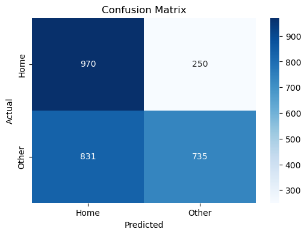

```
              precision    recall  f1-score   support

           H       0.54      0.80      0.64      1220
           X       0.75      0.47      0.58      1566

    accuracy                           0.61      2786
   macro avg       0.64      0.63      0.61      2786
weighted avg       0.66      0.61      0.61      2786
```

```python
y_true = result_df['FTR_mod']
y_pred = result_df['Prediction_mod']

cm = confusion_matrix(y_true, y_pred)

plt.figure(figsize=(6, 4))
sns.heatmap(cm, annot=True, fmt='d', cmap='Blues', xticklabels=['Home', 'Other'],
            yticklabels=['Home', 'Other'])
plt.xlabel('Predicted')
plt.ylabel('Actual')
plt.title('Confusion Matrix')
plt.show()

# precision = precision_score(y_true, y_pred, average='weighted')
# recall = recall_score(y_true, y_pred, average='weighted')
# f1 = f1_score(y_true, y_pred, average='weighted')
# accuracy = accuracy_score(y_true, y_pred)

report = classification_report(y_true, y_pred)
print(report)
```

## Match Results vs B365 Predictions

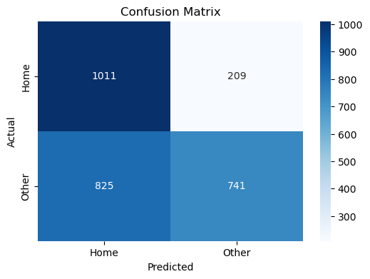

```
              precision    recall  f1-score   support

           H       0.55      0.83      0.66      1220
           X       0.78      0.47      0.59      1566

    accuracy                           0.63      2786
   macro avg       0.67      0.65      0.63      2786
weighted avg       0.68      0.63      0.62      2786
```

```python
y_true = result_df['FTR_mod']
y_pred = result_df['B365_mod']

cm = confusion_matrix(y_true, y_pred)

plt.figure(figsize=(6, 4))
sns.heatmap(cm, annot=True, fmt='d', cmap='Blues', xticklabels=['Home', 'Other'],
            yticklabels=['Home', 'Other'])
plt.xlabel('Predicted')
plt.ylabel('Actual')
plt.title('Confusion Matrix')
plt.show()

report = classification_report(y_true, y_pred)
print(report)
```

## B365 Predictions vs My Predictions

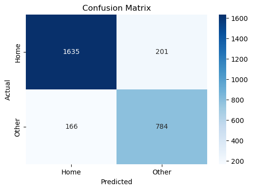

```
              precision    recall  f1-score   support

           H       0.91      0.89      0.90      1836
           X       0.80      0.83      0.81       950

    accuracy                           0.87      2786
   macro avg       0.85      0.86      0.85      2786
weighted avg       0.87      0.87      0.87      2786
```

```python
y_true = result_df['B365_mod']
y_pred = result_df['Prediction_mod']

cm = confusion_matrix(y_true, y_pred)

plt.figure(figsize=(6, 4))
sns.heatmap(cm, annot=True, fmt='d', cmap='Blues', xticklabels=['Home', 'Other'],
            yticklabels=['Home', 'Other'])
plt.xlabel('Predicted')
plt.ylabel('Actual')
plt.title('Confusion Matrix')
plt.show()

report = classification_report(y_true, y_pred)
print(report)
```

# Conclusion

## Hyperparameters

By using the poisosn distribution to predict the goals scored for each team, we now know that looking back 2 seasons gives us the best results in terms of accuracy.

## Results

Firstly, by directly comparing our predictions to the actual match results, we know that we had a 61% accuracy when predicting whether the home team won in a game in the premier league. But is this good or bad? it’s better than a coin toss but is it good enough? I used the B365 predictions as a standard to see whether or not this result was a decent attempt.

It turns out that by using the B365 predictions, it gives us a 63% accuracy of predicting the win of a home team in the Premier League which is 2%p higher than our prediction. Under the circumstance that we didn’t include compatability between the two teams, or injuries, recent match trends, and other factors that B365 probably used, I would conclude that it was a decent attempt.

So my predictions and B365’s predicitons had a similar accuracy, but did we have similar guesses for similar matches or did we guess differently in different games but just happenned to get the same accuracy. This could be done by evaluating the results of my predicitons to B365’s predictions. My predictions were 87% accurate in total and had an f1 score of 0.9 when it came to guessing the Home win of a match result meaning that we were guessing similarly in most cases.

## Future Improvement

As mentioned in the results section of the conclusion, other factors could be fed into the poisson model for better predictions. If we had data on injuries, additional transfers, trend of recent matches, international call-ups, how many games the club played in a given period of time compared to its opponent and other data, we could most likely improve our model to at least a similar efficiency with the B365 predictions.